# L2_linear_regression

NikolayNikolaev

2023-06-04

## Contents:

- James et al (google ISLR). Chapters 3-9
1. Regression (linear, polynomial,KNN)
2. Classification (logistic,LDA,QDA,KNN)
3. Cross validation and bootstrap
4. Model selection and regularization (lasso, ridge)
5. Non-linearities
6. Tree-based methods
7. Support vector machines

```r
library(ISLR) # to load all datasets used in the book
```

Statistical/Machine learning: set of tools for understanding data

Mainly divided in: 1. supervised –> you also observe y ex: polynomial regression

2. unsupervised –> you do not observe y Ex: cluster analysis

Onother importatn division: 1. Regression problem –> for quantitative Y Ex: local regression 2. Classification problem –> for qualitative Y Ex: discriminant analysis

Big assumption: asssume the existence of a relation
$$Y = f(X) + \epsilon$$
we want to estimate $f$ for two objectives: 1. to predict Y 2. inference on how X affects Y

We can estimate $f$ with 1. parametric models –> we assume a specific form for $f$ and then reduce the problem of estimating $f$ to the problem of estimating a set of parameters Ex: in linear regression $f(x)=a+bX$ Typically: high bias, low variance

2. nonparametric models –> do not assume a specific form Ex: spline Typically: low bias, high variance

For prediction, no method will exactly predict $Y$, since: - there is a part of error that can be reduced by the choice of an appropriate model (reducible error) - there is a part of error which is intrinsic of the $Y$ variabiliy (eps) (irreducible error)

Data (or part of data) we use to learn f(), is called training sample, which is different from the testing sample, over which you measure how well you estimated f()

In simple models, restrictive form of f

–> bias, but nonparametric models can lead to a phenomenon called overfitting:

we are explaining our data too well, that is we are following too much the dynamics in the current data, causing a poor performance in other datasets –> high variance of the estimate

we see: measure of performance ok on training data but worse on test data

how do we assess model accuracy? 1. In regression problems, Y is quantitative and then we measure the distance btw predicted and true Y through the Mean Square Error (MSE): mean((Y-Y.hat)^2) low MSE means a better model

If you measure MSE on the training data, you have Training MSE, but, if feasible, it is better to measure in on the test data (Test MSE). But: often you only have training data

–> methods to estimate Test MSE based on training data (validation and bootstrap)

–> Test and Training MSE can behave quite differently

On all methods, we assist to this trade-off between bias and variance. The test MSE can be decomposed in three parts: variance of f.hat, bias of f.hat and the irreducible variance of the statistical error

2. In classification problems, Y is qualitative, then we look at the performance measure called Training/Test error rate: mean(Y!=Y.hat)

statistical models for classification are called classifiers, since correct prediction of Y means attribution of the statistical unit to the correct class or category

An example of classifier: Bayes classifier, that assign units to that class with highest posterior probability

Another example if KNN classifier: (K nearest neighbours) assign unit to that class most frequent among the k units closest

# REGRESSION

### Chapter 3 of ISLR

### Supervised learning approach

I have a quantitative Y, that I want to predict according to some covariates/predictors/features X, ot I want to infer the relationship between X and Y

Simple linear regression #

Simple: unique X, and dependence btw X and Y assumed linear: Y approx beta0+beta1*X

```r
getwd()
```

```
## [1] "D:/Universita_Bicocca/02.Anno/ML_universita"
```

```r
D <- read.csv("data/Advertising.csv")
head(D)
```

```
##   X    TV radio newspaper sales
## 1 1 230.1  37.8      69.2  22.1
## 2 2  44.5  39.3      45.1  10.4
## 3 3  17.2  45.9      69.3   9.3
## 4 4 151.5  41.3      58.5  18.5
## 5 5 180.8  10.8      58.4  12.9
## 6 6   8.7  48.9      75.0   7.2
```

sales approx b0+b1*TV - b0 = intercept - b1 = slope

find linear relationship that best explains dependence in (x1,y1), (x2,y2),…

```r
D <- D[,-1] # remove first column
plot(D$TV,D$sales) # to have a first idea of relat.
M <- lm(D$sales~D$TV)  # lm stays for linear model
M
```

```
##
## Call:
## lm(formula = D$sales ~ D$TV)
##
## Coefficients:
## (Intercept)         D$TV
##     7.03259      0.04754
```

```r
summary(M) # to have more info
```

```
##
## Call:
## lm(formula = D$sales ~ D$TV)
##
## Residuals:
##     Min      1Q  Median      3Q     Max
## -8.3860 -1.9545 -0.1913  2.0671  7.2124
##
## Coefficients:
##             Estimate Std. Error t value Pr(>|t|)
## (Intercept) 7.032594   0.457843   15.36   <2e-16 ***
## D$TV        0.047537   0.002691   17.67   <2e-16 ***
## ---
## Signif. codes:  0 '***' 0.001 '**' 0.01 '*' 0.05 '.' 0.1 ' ' 1
##
## Residual standard error: 3.259 on 198 degrees of freedom
## Multiple R-squared:  0.6119, Adjusted R-squared:  0.6099
## F-statistic: 312.1 on 1 and 198 DF,  p-value: < 2.2e-16
```

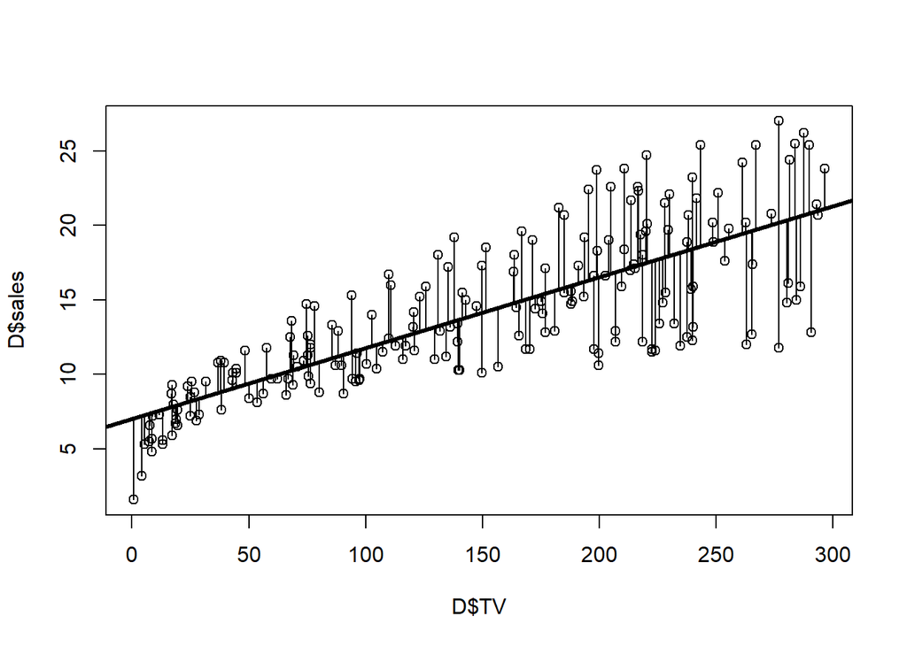

```r
abline(M,lwd=3) # to add the estimated regression lin
# optimal since it minimizes distances btw Y and Y.hat
segments(D$TV,D$sales,D$TV,M$fitted.values)
```

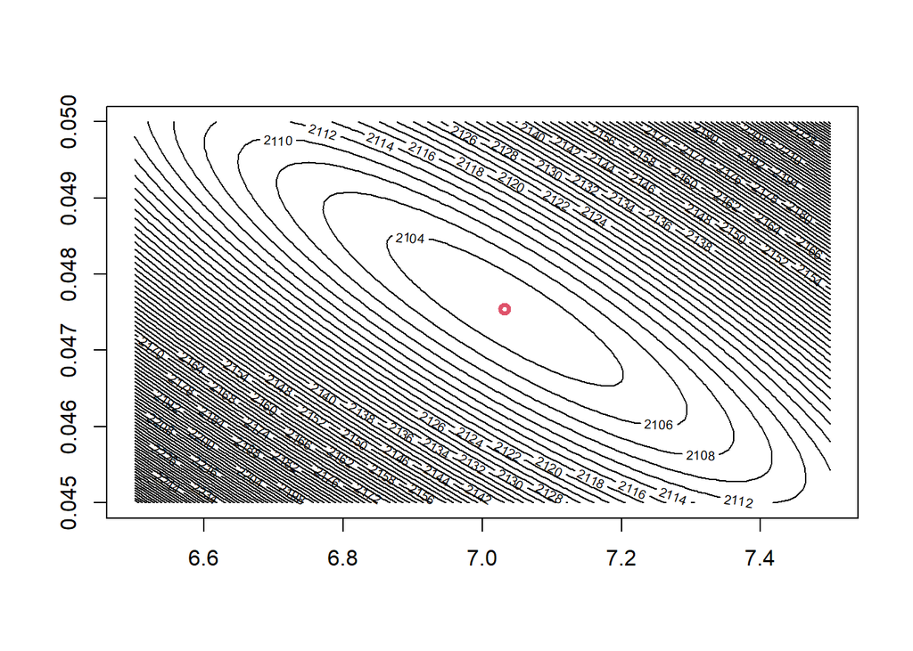

```r
RSS <- sum((D$sales-M$fitted.values)^2)  # optimal RSS

## Example on optimality of RSS
b0s <- seq(6.5,7.5,by=0.01)  # intercepts to try
b1s <- seq(0.045,0.05,length=length(b0s)) # slopes to try
RSS <- c() # to be filled
for(b1 in b1s){
  for(b0 in b0s){
    y.pred <- b0+b1*D$TV # predicted Y
    RSS.current <- sum((D$sales-y.pred)^2)
    RSS <- c(RSS,RSS.current)
  }
}
RSS <- matrix(RSS,length(b0s),length(b1s))
contour(b0s,b1s,RSS,nlevels = 100)
points(M$coefficients[1],M$coefficients[2],col=2,lwd=3)
```

```r
M$coefficients
```

```
## (Intercept)        D$TV
##  7.03259355  0.04753664
```

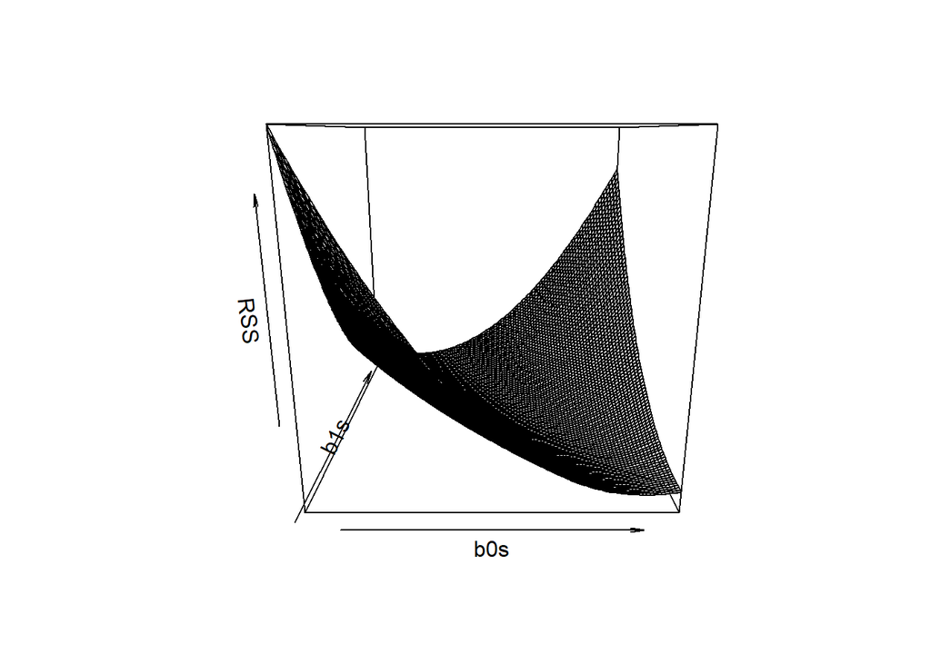

```r
persp(b0s,b1s,RSS)
```

Ex on the difference between population regression line and estimated (OLS) regression line:

Even if a linear relat exists, there is this difference

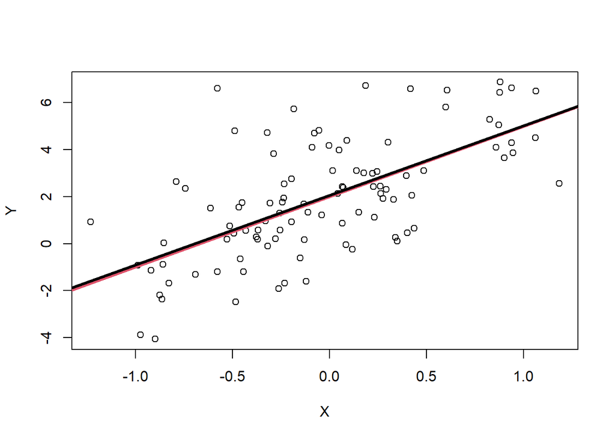

```r
X   <- rnorm(100,0,0.5) # covariate
eps <- rnorm(100,0,2)   # error
Y   <- 2+3*X+eps        # dependent var
plot(X,Y)
abline(2,3,col=2,lwd=3)  # pop regression line
abline(lm(Y~X),col=1,lwd=3) # estimated regression line
```

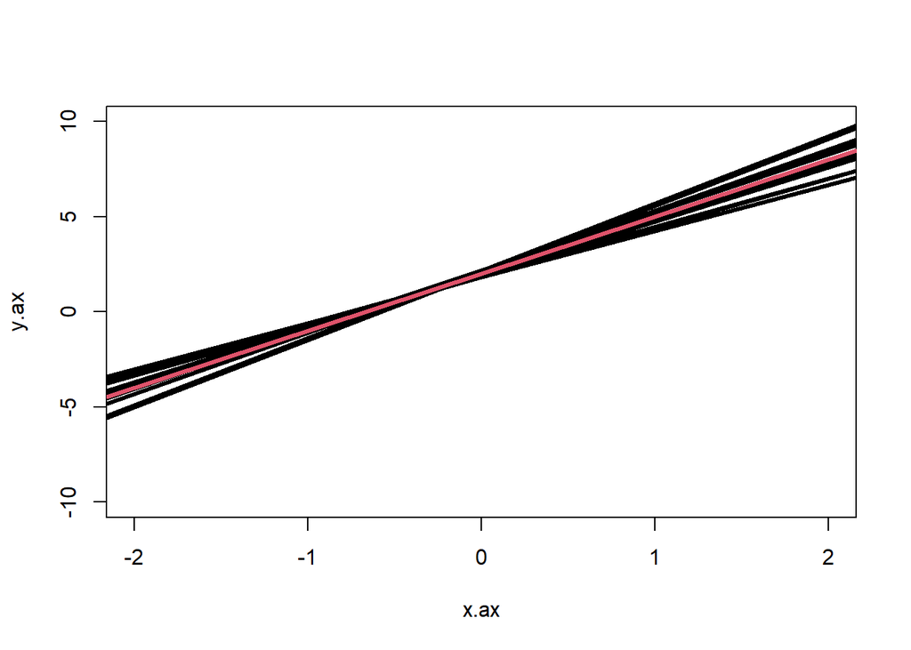

```r
# OLS line changes in each sample:
x.ax <- seq(-2,2,length=100) # x axis
y.ax <- seq(-10,10,length=100) # y axis
plot(x.ax,y.ax,type="n")
for(i in 1:10){ # 10 different samples
  X   <- rnorm(100,0,0.5) # covariate
  eps <- rnorm(100,0,2)   # error
  Y   <- 2+3*X+eps        # dependent var
  abline(lm(Y~X),col=1,lwd=3) # estimated regression line
}
abline(2,3,col=2,lwd=3)  # pop regression line
```

back to the advertising example:

richer output with

```r
M.summary <- summary(M)
M.summary$coefficients
```

```
##               Estimate  Std. Error  t value    Pr(>|t|)
## (Intercept) 7.03259355 0.457842940 15.36028 1.40630e-35
## D$TV        0.04753664 0.002690607 17.66763 1.46739e-42
```

both b0 and b1 signif different from 0 from the output, we also have the model accuracy

Two ways: RSE (residual standard error) and R2 1. RSE is a measure of lack of fit (low is better) RSE = sqrt(RSS/(n-2))

```r
M.summary # select model with lower RSE
```

```
##
## Call:
## lm(formula = D$sales ~ D$TV)
##
## Residuals:
##     Min      1Q  Median      3Q     Max
## -8.3860 -1.9545 -0.1913  2.0671  7.2124
##
## Coefficients:
##             Estimate Std. Error t value Pr(>|t|)
## (Intercept) 7.032594   0.457843   15.36   <2e-16 ***
## D$TV        0.047537   0.002691   17.67   <2e-16 ***
## ---
## Signif. codes:  0 '***' 0.001 '**' 0.01 '*' 0.05 '.' 0.1 ' ' 1
##
## Residual standard error: 3.259 on 198 degrees of freedom
## Multiple R-squared:  0.6119, Adjusted R-squared:  0.6099
## F-statistic: 312.1 on 1 and 198 DF,  p-value: < 2.2e-16
```

2. R^2 (proportion of variance explained by X) R^2 = 1 - RSS/TSS

```r
M.summary$r.squared
```

```
## [1] 0.6118751
```

# More examples on simple regressions:

```r
names(D)
```

```
## [1] "TV"        "radio"     "newspaper" "sales"
```

```r
M.radio <- lm(sales~radio,data = D)
summary(M.radio)$coeff
```

```
##              Estimate Std. Error   t value     Pr(>|t|)
## (Intercept) 9.3116381 0.56290050 16.542245 3.561071e-39
## radio       0.2024958 0.02041131  9.920765 4.354966e-19
```

# there is a linear ret also with radio

```r
M.news <- lm(sales~newspaper,data = D)
summary(M.news)$coeff
```

```
##               Estimate Std. Error   t value     Pr(>|t|)
## (Intercept) 12.3514071 0.62142019 19.876096 4.713507e-49
## newspaper    0.0546931 0.01657572  3.299591 1.148196e-03
```

there is a linear ret also with newspaper

Why should we use a unique model with all Xs in it? - with three simple lms, we are not able to predict sales for given investments in TV, radio, newsp - with three simple lms, we are neglecting the correlation among Xs

–> multiple lm , where the single coef expresses the dependence of that media with sales,keeping fixed investments in other media

A first simulated ex on multiple lm

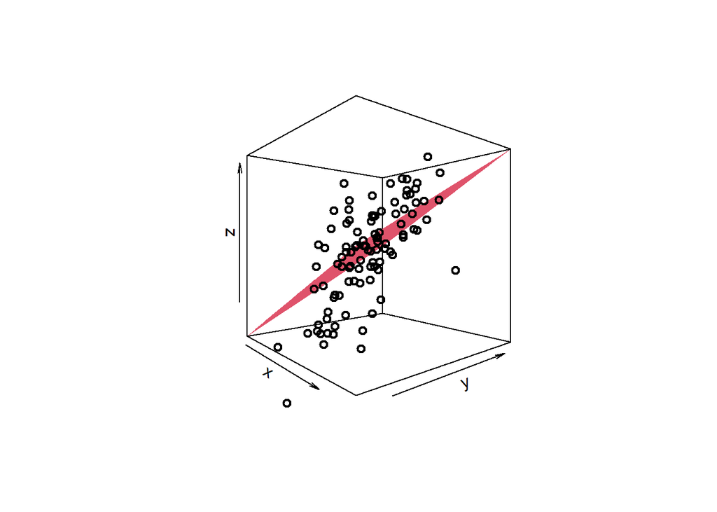

```r
x1 <- rnorm(100)
x2 <- rnorm(100)
y  <- 1+x1+2*x2+rnorm(100,0,2)
M  <- lm(y~x1+x2)
betas <- M$coefficients

# to visualize the residuals:
f <- function(x1,x2){
  y<-betas[1]+betas[1]*x1+betas[2]*x2
}
y.out <- outer(x1,x2,f) # y.out[i,j]=f(x1[i],x2[j])
plot.lm <- plot3D::persp3D(x1,x2,y.out,theta=50,phi=0,col=2)
# now we have a OLS plane, and to add points:
mypoints <- trans3d(x1,x2,y,plot.lm)
points(mypoints,lwd=2)
```

```r
# back to advertising:
M.all <- lm(sales~.,data=D)
# "." after ~ means "all others in the dataset"
round(summary(M.all)$coeff,4)
```

```
##             Estimate Std. Error t value Pr(>|t|)
## (Intercept)   2.9389     0.3119  9.4223   0.0000
## TV            0.0458     0.0014 32.8086   0.0000
## radio         0.1885     0.0086 21.8935   0.0000
## newspaper    -0.0010     0.0059 -0.1767   0.8599
```

incoherence with simple lms since now newsp in not linked to sales apparent incoherence: in multiple lm, the slope is the effect of newsp on sales, keeping fixed TV and radio investiments. In simple lm, the slope in the marginal effect on newsp on sales (without considering TV and radio)

```r
cor(D)
```

```
##                   TV      radio  newspaper     sales
## TV        1.00000000 0.05480866 0.05664787 0.7822244
## radio     0.05480866 1.00000000 0.35410375 0.5762226
## newspaper 0.05664787 0.35410375 1.00000000 0.2282990
## sales     0.78222442 0.57622257 0.22829903 1.0000000
```

high correlation btw newsp and radio: I tend to see higher newsp investments when radio investments are high –> then I can confuse the effect on sales

Absurd example: lm reveals a dependence between ice cream sales and shark attacks –> if you include also temperature this dependnce disappears

Important questions: 1. Is at least one X useful? 2. Do all predictors help to explain Y? 3. How well the model fits the data? 4. Given a value of Xs, how do you predict Y?

1. answer looking at the F statistic

```r
summary(M.all)
```

```
##
## Call:
## lm(formula = sales ~ ., data = D)
##
## Residuals:
##     Min      1Q  Median      3Q     Max
## -8.8277 -0.8908  0.2418  1.1893  2.8292
##
## Coefficients:
##              Estimate Std. Error t value Pr(>|t|)
## (Intercept)  2.938889   0.311908   9.422   <2e-16 ***
## TV           0.045765   0.001395  32.809   <2e-16 ***
## radio        0.188530   0.008611  21.893   <2e-16 ***
## newspaper   -0.001037   0.005871  -0.177     0.86
## ---
## Signif. codes:  0 '***' 0.001 '**' 0.01 '*' 0.05 '.' 0.1 ' ' 1
##
## Residual standard error: 1.686 on 196 degrees of freedom
## Multiple R-squared:  0.8972, Adjusted R-squared:  0.8956
## F-statistic: 570.3 on 3 and 196 DF,  p-value: < 2.2e-16
```

since pval small –> reject null hypothesis and at least one regressor is useful

I am testing H0: beta1=beta2=beta3=0 vs H1: betai<>0 for some i in {1,2,3} we can then remove newsp from lm:

```r
M.radioTV <- lm(sales~.-newspaper,data=D)
```

An edvantage is that I can predict sales in correspondence of given values of Xs

```r
predict(M.radioTV,data.frame(TV=100,radio=20,
                             newspaper=100),
        interval = "confidence",level=0.95)
```

```
##        fit      lwr      upr
## 1 11.25647 10.98525 11.52768
```

to predict average sales when we invest 100 in TV,…

Why do I need to look at the F test if I already have t tests associated to the single covariates?

Are F test and t tests always coherent? If not, what should I do?

Not always coherent and priority to F test

Reason: t tests are affected by a problem of multiple HT it becomes easier and easier to find a false significant coefficient as you increase the num of Xs

Example: p=100 regressors and Type I-error prob is alpha=0.05, then you expect 5 t tests to be significant when in reality all betas are 0

2. Are all the Xs useful for predicting Y? variable selection problem: identify redundant Xs and remove from the model. Difficult problem since the num of models to compare is huge even for a moderate num of regressors

With p=2 regressors: we compare (1) null model with no Xs, (2) full model with both Xs, (3) model with only X1, (4) model with only X2 and then we use R^2 (adjusted) or Mallows Cp, AIC, BIC In general, with p regressors, 2^p models to compare easier to become huge –> methods to compare models without exploring the whole model space:

1. forward selection. You start from the null model. You include only one X, the one showing lowest RSS (comparison among p models). Then you include another X among the p-1 remaining, the one showing lowest RSS. Continue in this way up to the point where none of the remaining predictors are significant if included
2. backward selection. You start from the full model and then you remove that X that is least significant (highest pvalue) and so on, up to the point where pvals of included Xs are below a given threshold
3. mixed selection. Backward selection can’t be used for high-dimensional problems (p>=n) and forward selection is a greedy approach (X already included can’t be exluded anymore, even if other includes regressors make this X not significant). You start from the null model

You include that X with lowest RSS (like in forward), but when an X has pval above a threshold, this is excluded (like in backward). Up to the point where all pvals of included Xs are below a threshold and all Xs exluded wouls not be significant if included